# LAB Describing Longitudinal Data

Author

A.Teixeira-Pinto & J. Harezlak

# Examples in the slides

Required libraries for different parts of the analysis.

```r
library(gtsummary)   # tables
library(tidyverse)   # function pivot_longer and pivot_wider
library(ggplot2)     # plots
library(ggalluvial)
```

## Dataset

**Dataset**: `crp2.csv`

**Description**: 120 patients admitted to intensive care (ICU) with sepsis. C-reactive protein (CRP) is a marker of inflammation and, potentially, a marker of sepsis resolution. CRP was measured over 6 days (`crp1`,…`crp6`) or until discharge/death (`discharge_r`).

**Other variables**:

- SAPS - severity score measured within the first 24h in the ICU
- age - age at admission
- SEX - Male / Female
- SEPSIS - category of sepsis (Sepsis/Severe Sepsis/Septic Shock)
- antib_1h - was antibiotherapy administer within the first hour in ICU (No/Yes)

Let’s load the data and create a summary table

```r
#Read the data from a shared dropbox folder
  crp.Data.wide <- read.csv("https://www.dropbox.com/scl/fi/c5r8asu1o40ij7blxxwkq/crp2.csv?rlkey=cmxluw3gqo14mgkrhf6ta4cet&dl=1")

#Table summarizing the data
  head(crp.Data.wide)
```

```
    ID age SAPS crp1 crp2 crp3 crp4 crp5 crp6 antib_1h discharge        SEPSIS
1 1467  57   41  1.7 21.0 21.0   NA   NA  9.2       No     Alive Severe Sepsis
2 4098  38   28  1.8 12.9 14.2  7.4  4.0  2.8       No     Alive Severe Sepsis
3 4022  43   24  1.9  7.8  9.9  9.5 11.1  6.4      Yes     Alive        Sepsis
4  699  59   65  1.9  1.5  1.1  1.4  1.6   NA       No      Dead  Septic Shock
5 2865  68   45  1.9  1.3 14.1  7.6  6.9   NA      Yes     Alive Severe Sepsis
6  663  70   45  2.0  7.2  4.3  3.0  1.8  2.8       No     Alive Severe Sepsis
   SEX
1 Male
2 Male
3 Male
4 Male
5 Male
6 Male
```

```r
  tbl_summary(crp.Data.wide)
```

| **Characteristic** | **N = 120**<sup>1</sup> |
| --- | --- |
| ID | 2,815 (1,521, 3,877) |
| age | 65 (49, 76) |
| SAPS | 49 (37, 62) |
| Unknown | 2 |
| crp1 | 12 (5, 17) |
| crp2 | 13 (9, 21) |
| Unknown | 12 |
| crp3 | 14 (8, 23) |
| Unknown | 17 |
| crp4 | 11 (7, 20) |
| Unknown | 22 |
| crp5 | 8 (5, 18) |
| Unknown | 29 |
| crp6 | 8 (3, 12) |
| Unknown | 34 |
| antib_1h | 66 (55%) |
| discharge |  |
| Alive | 91 (76%) |
| Dead | 29 (24%) |
| SEPSIS |  |
| Sepsis | 13 (11%) |
| Septic Shock | 60 (50%) |
| Severe Sepsis | 47 (39%) |
| SEX |  |
| Female | 42 (35%) |
| Male | 78 (65%) |

<sup>1</sup> Median (Q1, Q3); n (%)

## Changing the data structure

### Wide to long

```r
crp.Data <- pivot_longer(data = crp.Data.wide,
                         cols = c(crp1, crp2, crp3, crp4, crp5, crp6), #cols = crp1:crp6
                         names_to = "day",
                         names_transform = list(day = as.numeric), #day as number
                         values_to = "crp",
                         names_prefix = "crp",
                         values_drop_na=TRUE)
head(crp.Data)
```

```
# A tibble: 6 × 9
     ID   age  SAPS antib_1h discharge SEPSIS        SEX     day   crp
  <int> <int> <int> <chr>    <chr>     <chr>         <chr> <dbl> <dbl>
1  1467    57    41 No       Alive     Severe Sepsis Male      1   1.7
2  1467    57    41 No       Alive     Severe Sepsis Male      2  21
3  1467    57    41 No       Alive     Severe Sepsis Male      3  21
4  1467    57    41 No       Alive     Severe Sepsis Male      6   9.2
5  4098    38    28 No       Alive     Severe Sepsis Male      1   1.8
6  4098    38    28 No       Alive     Severe Sepsis Male      2  12.9
```

### Long to wide

```r
crp.Data.wide <- pivot_wider(crp.Data,
                             names_from = "day",
                             values_from=crp )
```

## Plotting longitudinal data

### Spaghetti plot

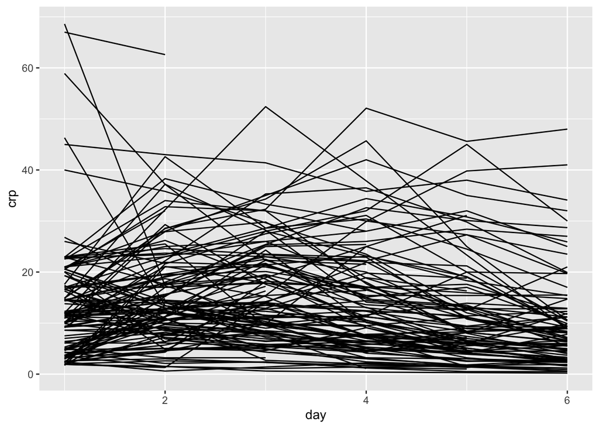

```r
#basic plot
ggplot(data = crp.Data,
       aes(x=day, y=crp, group=ID)) +
  geom_line()
```

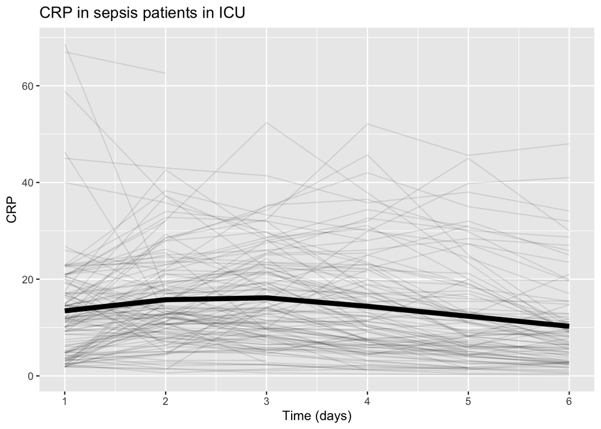

```r
#advanced with mean profile line
ggplot(data = crp.Data,
       aes(x=day, y=crp, group=ID)) +
  geom_line(alpha=.1) + #transparency to lines
  scale_x_continuous(breaks=c(1:6)) + #x-axis 1,2...,6
  labs(title="CRP in sepsis patients in ICU", x = "Time (days)", y = "CRP") +
  stat_summary(fun=mean, na.rm=T, #adds the means by year
               aes(group="none"),
geom="line", lwd=2, show.legend = F) +
  stat_summary(fun.data=mean_cl_boot, #adds the 95%CI
               aes(group="none"),
               geom="errorbar",
               lwd=1,
               width=.1,
show.legend = F)
```

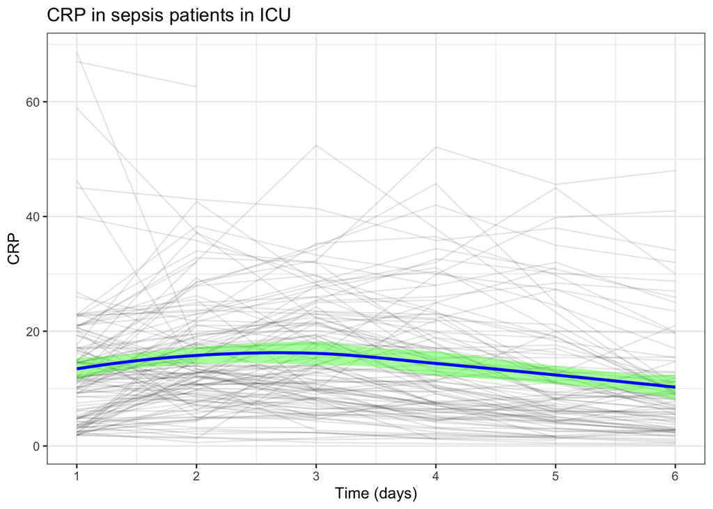

```r
#advanced with a smooth trend line
ggplot(data = crp.Data,
       aes(x=day, y=crp, group=ID)) +
  geom_line(alpha=.1) + #transparency to lines
  scale_x_continuous(breaks=c(1:6)) + #x-axis 1,2...,6
  labs(title="CRP in sepsis patients in ICU", x = "Time (days)", y = "CRP") +
geom_smooth(method = loess, #adds a smooth line
            aes(group="none"), #otherwise plots 1 line per ID
            se=T, # 95% confidence band
            fill = "green", #colour of conf band
            color="blue") + #colour of the line
  theme_bw() #theme
```

### Violin plot

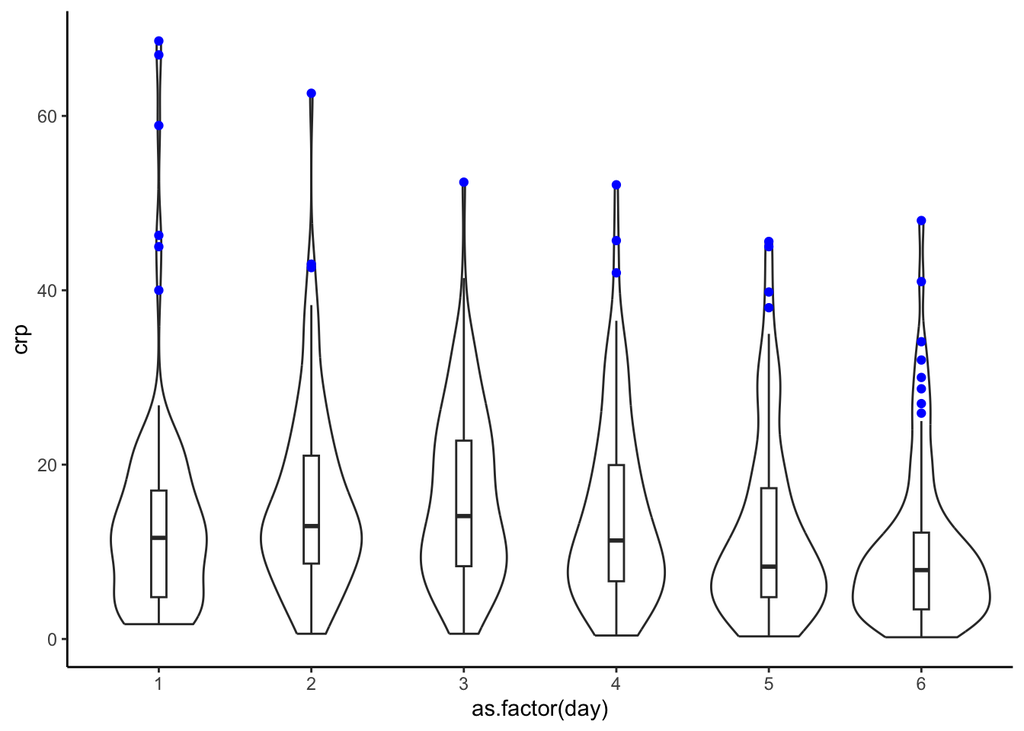

```r
#geom_violin will do the job
ggplot(crp.Data,
       aes(x=as.factor(day), y=crp)) +
  geom_violin() +
  geom_boxplot(width = 0.1, outlier.colour = "blue") + #boxplot inside
  theme_classic()
```

### Binary outcome and continuous time

The plot below gives you a glimpse of the data when you have a categorical outcome over a continuous time.

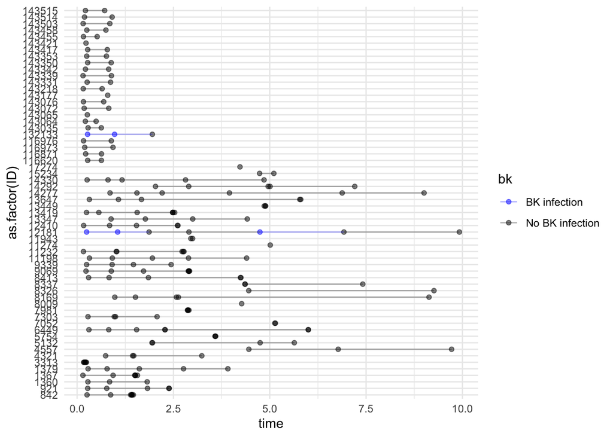

```r
bk.Data <- read.csv("https://www.dropbox.com/s/1maznm125j7vm5t/bk.csv?dl=1")
bk.Data$bk <-ifelse(bk.Data$bk==1, "BK infection", "No BK infection")

ggplot(data = bk.Data[1:200,],   #select just a few patients
       aes(x=time, y=as.factor(ID), colour=bk)) +
  scale_colour_manual(values = c("No BK infection" = "black",
                                 "BK infection" = "blue")) +
  geom_point(alpha=.5) +
  geom_line(aes(group=ID), alpha=.3) +
  theme_minimal()
```

### Categorical outcome and discrete time .

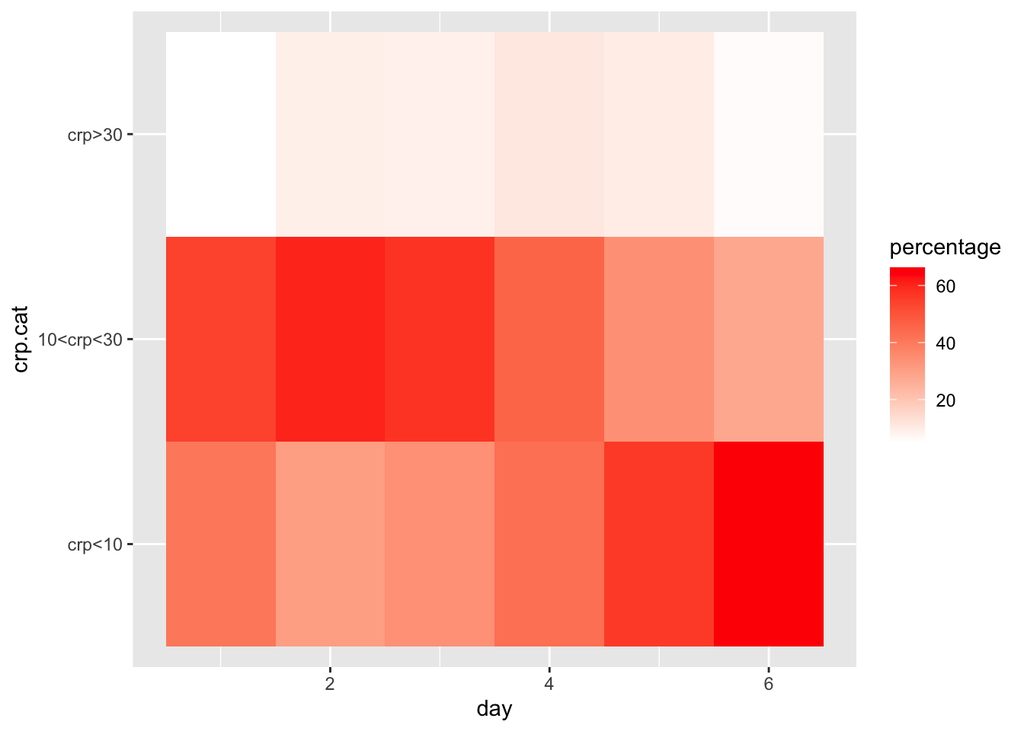

```r
#create categories for CKR
new.CKR <- crp.Data %>%
  mutate(crp.cat = ifelse(crp<10, "crp<10",
                             ifelse(crp<30, "10<crp<30",
                                           "crp>30"))) %>%
  mutate(crp.cat=factor(crp.cat,
                           levels=c("crp<10","10<crp<30",
                                    "crp>30")))

#produce the percentages of patients in each group by day
  table.new.CKR <- new.CKR %>%
    select(c("crp.cat", "day")) %>%
    count(day, crp.cat) %>%
    group_by(day) %>%
    mutate(percentage = n / sum(n) * 100)

ggplot(table.new.CKR,
       aes(x=day, y=crp.cat, fill=percentage)) +
  scale_fill_gradient(low = "white", high = "red") +
  geom_tile()
```

The alluvial plots can also be used to plot these data.

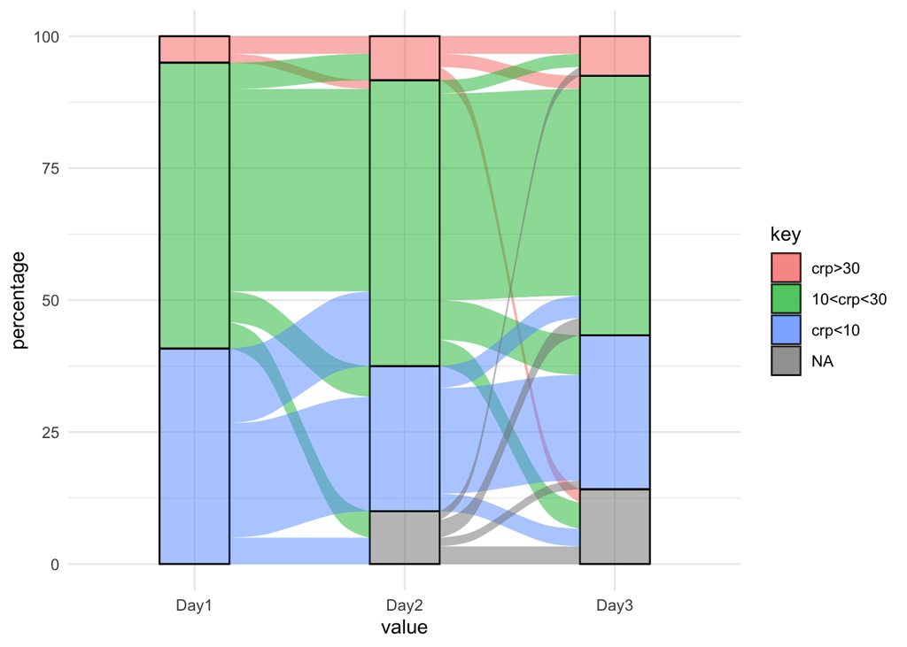

```r
library(ggalluvial)

freq_table_long <- new.CKR %>%
  pivot_wider(id_cols = ID,
              names_from = day,
              values_from = crp.cat,
              names_prefix = "Day") %>%
  count(Day1, Day2, Day3) %>%
  mutate(id = row_number())

freq_table_long2 <- gather(freq_table_long, value, key, -n, -id) %>%
  mutate(key = as_factor(key)) %>%
  mutate(key=fct_relevel(key,c("crp>30", "10<crp<30", "crp<10"))) %>%
  group_by(value) %>%
  mutate(percentage = n / sum(n) * 100)

ggplot(freq_table_long2, aes(x = value, y = percentage,
                          stratum = key, fill = key,
                          alluvium = id)) +
  geom_stratum(alpha = .5) +
  geom_flow()+
  theme_minimal()
```

# Exercises

## Dataset

**Dataset**: tlc.csv

**Description**: The Treatment of Lead-Exposed Children (TLC) trial was a placebo-controlled, randomized study of succimer (a chelating agent) in 100 children with blood lead levels of 20-44 micrograms/dL.

**Variables**:

- id a factor with 100 levels
- trt - treatment arm ( placebo and succimer)
- y0 to y6 - lead measurement over 6 weeks (baseline, week1, week4, week6)

```r
 #Read the TLC datset
 tlc <- read.csv("https://www.dropbox.com/s/dj6ssrn3pmqtrnd/tlc.csv?dl=1")
 head(tlc)
```

```
  id trt   y0   y1   y4   y6
1  1   P 30.8 26.9 25.8 23.8
2  2   A 26.5 14.8 19.5 21.0
3  3   A 25.8 23.0 19.1 23.2
4  4   P 24.7 24.5 22.0 22.5
5  5   A 20.4  2.8  3.2  9.4
6  6   A 20.4  5.4  4.5 11.9
```

## Questions

##### 1. The data is in the wide format. Create a long format version of the data

```r
 tlc.long <- pivot_longer(       ,
                          cols=.     ,
                          names_to = "week",
                          names_transform = list(week = as.numeric), #day as number
                          values_to = "lead",
                          names_prefix = "y",
                          values_drop_na=TRUE)
```

```r
 tlc.long <- pivot_longer(tlc,
                          cols=y0:y6,
                          names_to = "week",
                          names_transform = list(week = as.numeric),   #day as number
                          values_to = "lead",
                          names_prefix = "y",
                          values_drop_na=TRUE)
```

##### 2. Create a spaghetti plot will all the observations across the 6 weeks (try to colour each patient’s line with a different colour)

```r
 ggplot(tlc.long, aes(x=    , y=     , group=.   , colour=as.factor(    ))) +
   geom_line(show.legend = F)
```

```r
 ggplot(tlc.long, aes(x=week, y=lead, group=id, colour=as.factor(id))) +
   geom_line(show.legend = F)
```

```r
 ggplot(tlc.long, aes(x=    , y=     , group=   , colour=as.factor(    ))) +
  geom_line(show.legend = F) +
  facet_grid(     )
```

```r
ggplot(tlc.long, aes(x=week, y=lead, group=id, colour=as.factor(id))) +
  geom_line(show.legend = F) +
  facet_grid(cols=vars(trt))
```

```r
 ggplot(tlc.long, aes(x=    , y=     , group=   , colour=as.factor(    ))) +
  geom_line(show.legend = F) +
  facet_grid(     ) +
  stat_summary(fun=       , aes(group="none"),
               geom="line", lwd=2, show.legend = F)
```

```r
ggplot(tlc.long, aes(x=week, y=lead, group=id, colour=as.factor(id))) +
  geom_line(show.legend = F) +
  facet_grid(cols=vars(trt)) +
  stat_summary(fun=mean, aes(group="none"),
               geom="line", lwd=2, show.legend = F)
```

##### 5. Add, to the plot above (#4), the error bars the for mean lead at each week.

```r
 ggplot(tlc.long, aes(x=    , y=     , group=   , colour=as.factor(    ))) +
  geom_line(show.legend = F) +
  facet_grid(     )
  stat_summary(fun=       , aes(group="none"),
               geom="line", lwd=2, show.legend = F) +
  stat_summary(fun.data=     ,
               aes(group="none"),
               geom="        ",
               lwd=1, width=.2, show.legend = F)
```

```r
ggplot(tlc.long, aes(x=week, y=lead, group=id, colour=as.factor(id))) +
  geom_line(show.legend = F) +
  facet_grid(cols=vars(trt)) +
  stat_summary(fun=mean, aes(group="none"),
               geom="line", lwd=2, show.legend = F) +
  stat_summary(fun.data=mean_cl_boot,
               aes(group="none"),
               geom="errorbar",
               lwd=1, width=.2, show.legend = F)
```

##### 6. Add, to the plot in (#4), a smooth trend line using geom_smooth()

```r
 ggplot(tlc.long, aes(x=    , y=     , group=   , colour=as.factor(    ))) +
  geom_line(show.legend = F) +
  facet_grid(     ) +
       geom_smooth(                     )
```

```r
ggplot(tlc.long, aes(x=week, y=lead, group=id, colour=as.factor(id))) +
  geom_line(show.legend = F) +
  facet_grid(cols=vars(trt)) +
  geom_smooth(aes(group="none"),
              show.legend = F, colour="black")
```

```r
 ggplot(tlc.long, aes(x=    , y=     , group=   , colour=as.factor(    ))) +
  geom_line(show.legend = F) +
  facet_grid(     ) +
       geom_smooth(                     ) +
```

```r
ggplot(tlc.long, aes(x=week, y=lead, group=id, colour=as.factor(id))) +
  geom_line(show.legend = F, alpha=.3) +
  facet_grid(cols=vars(trt)) +
  geom_smooth(aes(group="none"),
              show.legend = F, colour="black") +
theme_minimal()
```